# Analysis of Environmental Data - Lab Exercise #12

Sarah Guitart

Students I Collaborated With: Ian Eggleston

### Q1

```r
library(here)
bird <- read.csv(here("data", "bird.sub.csv"))
hab <- read.csv(here("data", "hab.sub.csv"))
birdhab <- merge(bird, hab)
dim(birdhab)
```

```
[1]  30 159
```

```r
fit_1 <- lm(BRCR ~ ls, data = birdhab)
fit_1_coefs = coefficients(fit_1)
fit_1_summary = summary(fit_1)
sd_obs <- fit_1_summary$sigma
int_obs <- fit_1_coefs[1]
slope_obs <- fit_1_coefs[2]
```

```r
linear_simulator = function(x, y_int, slope, st_dev)
{
  noise = rnorm(length(x), mean = 0, sd = st_dev)
  return(slope * x + y_int + noise)
}
linear_sim_fit = function(x, slope, y_int, st_dev)
{
  y_sim = linear_simulator(
    x = x,
    y_int = y_int,
    slope = slope,
    st_dev = st_dev
  )
    fit_sim = lm(y_sim ~ x)
  return(fit_sim)
}
```

```r
alpha = 0.05
n_sims = 30
p_vals = numeric(n_sims)
sample_sizes = seq(2, 20)
sample_size_powers = numeric(length(sample_sizes))
max_x = max(birdhab$ls)
for(j in 1:length(sample_sizes))
{
  x_vals = seq(0, max_x, length.out = sample_sizes[j])

  for(i in 1:n_sims)
  {
    fit_sim = linear_sim_fit(
      x = x_vals,
      y_int = int_obs,
      slope = slope_obs,
      st_dev = sd_obs
    )
    p_vals[i] = summary(fit_sim)$coefficients[2, 'Pr(>|t|)']
  }
  sample_size_powers[j] = sum(p_vals < alpha) / n_sims
}
sim_sample_size =
  data.frame(
    sample_size = sample_sizes,
    power       = sample_size_powers)
```

*Include your final plot in your lab report.*

```r
fit_lowess_30 = loess(power ~ sample_size, data = sim_sample_size, span = 0.3)
newdata_sample_size = data.frame(sample_size = seq(2, 20, length.out = 100))
plot(
  x = newdata_sample_size$sample_size,
  y = predict(fit_lowess_30, newdata = newdata_sample_size),
  type = "l",
  ylab = "Statistical Power", xlab = "Sample Size", main = "Sample Size/Power, LOWESS: 30%")
points(power ~ sample_size, data = sim_sample_size, col = "red", pch = 16)
```

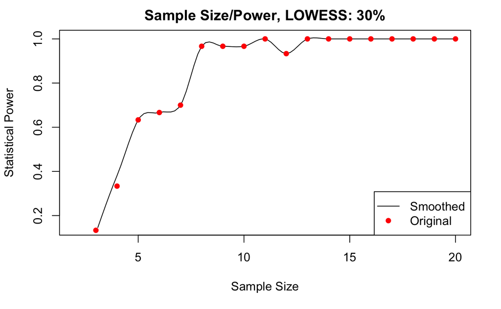

```r
legend("bottomright", legend = c("Smoothed", "Original"), col = c("black", "red"), lty = c(1, NA), pch = c(NA, 16))
```

### Q2

```r
dat_dispersal <- read.csv(here("data", "dispersal.csv"))
ricker_fun = function(x, a, b)
{
  return(a * x * exp(-b * x))
}
```

```r
fit_ricker_nls = nls(
  disp.rate.ftb ~ ricker_fun(dist.class, a, b),
  data = dat_dispersal,
  start = list(b = 0, a = 1))
summary(fit_ricker_nls)
```

```
Formula: disp.rate.ftb ~ ricker_fun(dist.class, a, b)

Parameters:
  Estimate Std. Error t value Pr(>|t|)
b 0.003586   0.000913   3.928  0.00201 **
a 0.004471   0.001889   2.367  0.03558 *
---
Signif. codes:  0 ‘***’ 0.001 ‘**’ 0.01 ‘*’ 0.05 ‘.’ 0.1 ‘ ’ 1

Residual standard error: 0.2149 on 12 degrees of freedom

Number of iterations to convergence: 17
Achieved convergence tolerance: 9.065e-06
  (1 observation deleted due to missingness)
```

*Include your plot in your lab report.*

```r
dist_newdata = data.frame(dist.class = seq(0, 1600, length.out = 1600))
plot(dat_dispersal$dist.class, dat_dispersal$disp.rate.ftb,
    xlim = c(0, 1500), xlab = "Distance Class", ylab = "Standardized Dispersal Rate",
    main = "Marbled Salamander First Time Breeders - Ricker Model", pch = 17)
lines(predict(fit_ricker_nls, newdata = dist_newdata), col = "blue", lwd = 2)
```

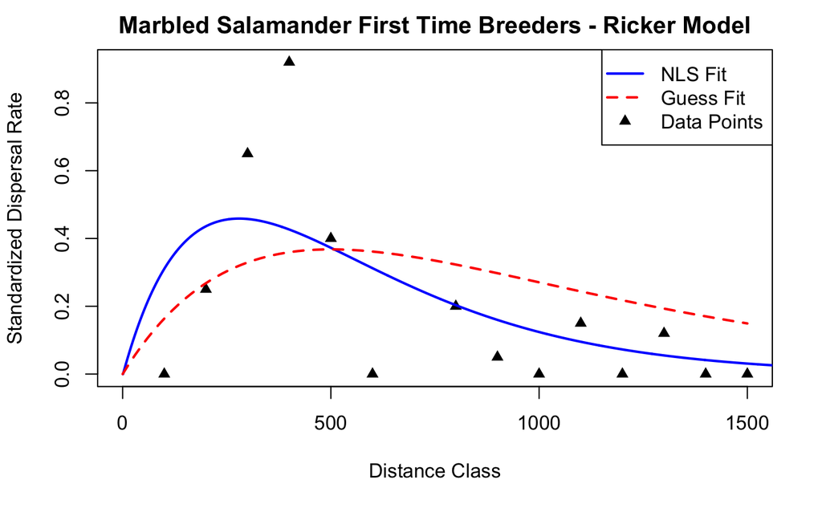

```r
curve(ricker_fun(x, .6/300, 1/500), add = TRUE, lty = 2, col = "red", lwd = 2)
legend("topright", legend = c("NLS Fit", "Guess Fit", "Data Points"), lwd = c(2,2,NA), lty = c(1,2,NA), col = c("blue", "red", "black"), pch = c(NA,NA,17))
```

### Q3

*What are the AIC values for each of the 4 models?*

```r
dat_bird = read.csv(here("data", "bird.sta.csv"))
dat_habitat = read.csv(here("data", "hab.sta.csv"))
dat_all = merge(dat_bird, dat_habitat)
dat_all$GCKI_pres = dat_all$GCKI > 0
fit_gcki_slope = glm(GCKI_pres ~ slope, data = dat_all, family = binomial)
fit_gcki_ba_tot = glm(GCKI_pres ~ ba.tot, data = dat_all, family = binomial)
fit_gcki_both_additive = glm(GCKI_pres ~ slope + ba.tot, data = dat_all, family = binomial)
fit_gcki_both_interactive = glm(GCKI_pres ~ slope * ba.tot, data = dat_all, family = binomial)
```

```r
AIC(
  fit_gcki_ba_tot,
  fit_gcki_slope,
  fit_gcki_both_additive,
  fit_gcki_both_interactive)
```

|  | df | AIC |
| --- | --- | --- |
| fit_gcki_ba_tot | 2 | 1369.379 |
| fit_gcki_slope | 2 | 1432.615 |
| fit_gcki_both_additive | 3 | 1355.951 |
| fit_gcki_both_interactive | 4 | 1353.007 |

A: The AIC values for the four models are 1369.379 for the basal area model, 1432.615 for the slope model, 1355.951 for the additive model, and 1353.007 for the interactive model.

### Q4

*Which model would you choose, and why?*

A: I would choose the interactive model because it has the lowest AIC value, at 1353.007. This is because the smaller the AIC value, the better the fit of the model.

### Q5

*Based on the model coefficient table of your chosen model, describe the direction and significance of the relationship(s) of the predictor variable or variables to the binary response. Make sure your answer is in terms of the ecological context.*

```r
summary(fit_gcki_both_interactive)
```

```
Call:
glm(formula = GCKI_pres ~ slope * ba.tot, family = binomial,
    data = dat_all)

Deviance Residuals:
    Min       1Q   Median       3Q      Max
-3.7433  -1.0717   0.6444   1.0862   1.4846

Coefficients:
               Estimate Std. Error z value Pr(>|z|)
(Intercept)  -0.2643673  0.2500615  -1.057   0.2904
slope        -0.0040863  0.0045338  -0.901   0.3674
ba.tot        0.0532974  0.0109776   4.855  1.2e-06 ***
slope:ba.tot -0.0004131  0.0001866  -2.214   0.0269 *
---
Signif. codes:  0 ‘***’ 0.001 ‘**’ 0.01 ‘*’ 0.05 ‘.’ 0.1 ‘ ’ 1

(Dispersion parameter for binomial family taken to be 1)

    Null deviance: 1439.7  on 1045  degrees of freedom
Residual deviance: 1345.0  on 1042  degrees of freedom
AIC: 1353

Number of Fisher Scoring iterations: 4
```

A: From the model coefficient table, we can see that the total basal area and the basal area/slope interaction both have associations with Golden-crowned Kinglet presence/absence, as their p-values are below 0.05. The total basal area has a positive relationship of 0.05, while the interaction of slope and total basal area has a negative relationship of -0.0004. Slope by itself also showed a negative association with kinglet presence/absence, but that relationship is not significant.

### Q6

```r
n = 500
slope_newdata = data.frame(
  slope = seq(
    from = min(dat_all$slope, na.rm = T),
    to = max(dat_all$slope, na.rm = T),
    length.out = n
  )
)
n = 500
ba_newdata = data.frame(
  ba.tot = seq(
    from = min(dat_all$ba.tot, na.rm = T),
    to = max(dat_all$ba.tot, na.rm = T),
    length.out = n
  )
)
```

```r
slope_newdata$gcki_predicted =
  predict(
    fit_gcki_slope,
    newdata = slope_newdata,
    type = "response"
  )
ba_newdata$gcki_predicted =
  predict(
    fit_gcki_ba_tot,
    newdata = ba_newdata,
    type = "response"
  )
```

*Include your two single-predictor model plots in your report.*

```r
par(mfrow = c(2, 1))
plot(
  GCKI_pres ~ slope, data = dat_all, axes = FALSE, ylim = c(-0.2,1.2),
  xlab = "Percent Slope", ylab = "", main = "GCKI Presence/Absence by % Slope",
   pch = 16, col = adjustcolor("red", alpha.f = 0.1))
axis(1, at = seq(0,110, by = 10))
```

```r
axis(2, at = c(0,1), labels = c("Absent", "Present"), las = 2)
box()
```

```r
lines(gcki_predicted ~ slope, data = slope_newdata)
plot(
  GCKI_pres ~ ba.tot, data = dat_all, axes = FALSE, ylim = c(-0.2, 1.2),
  xlab = "Basal Area", ylab = "", main = "GCKI Presence/Absence by Basal Area",
  pch = 16, col = adjustcolor("blue", alpha.f = 0.1))
```

```r
axis(1, at = seq(0,210, by = 50))
axis(2, at = c(0,1), labels = c("Absent", "Present"), las = 2)
```

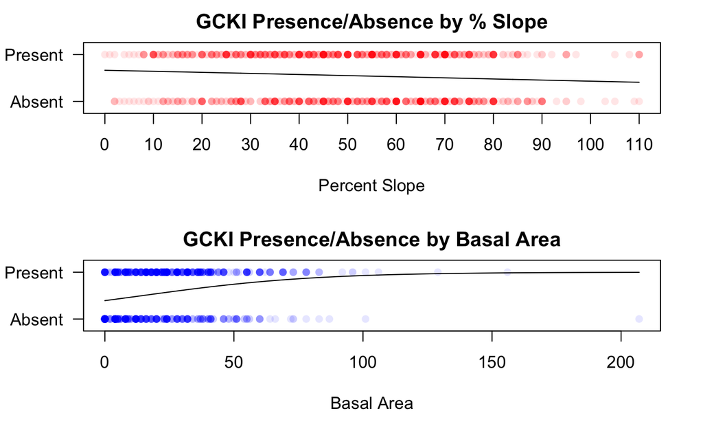

```r
box()
lines(gcki_predicted ~ ba.tot, data = ba_newdata)
```

### Q7

```r
n = 50
ba.tot = seq(
  from = min(dat_all$ba.tot, na.rm = T),
  to = max(dat_all$ba.tot, na.rm = T),
  length.out = n)
slope = seq(
  from = min(dat_all$slope, na.rm = T),
  to = max(dat_all$slope, na.rm = T),
  length.out = n)
new_dat_all = expand.grid(
  ba.tot = ba.tot,
  slope = slope)
new_dat_all$pred_add = predict(
  fit_gcki_both_additive,
  newdata = new_dat_all,
  type = "response")
new_dat_all$pred_int = predict(
  fit_gcki_both_interactive,
  newdata = new_dat_all,
  type = "response")
z_gcki_add = matrix(
  new_dat_all$pred_add,
  nrow = length(ba.tot),
  byrow = FALSE)
z_gcki_int = matrix(
  new_dat_all$pred_int,
  nrow = length(ba.tot),
  byrow = FALSE)
```

*Include contour plots (or interactive 3D perspective plots) in your report.*

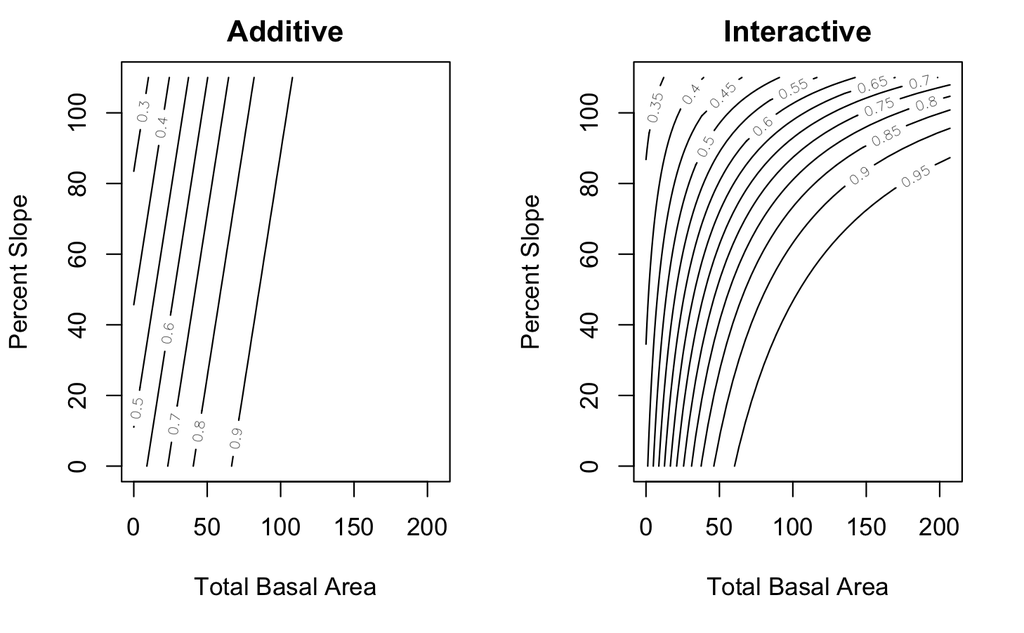

```r
par(mfrow = c(1, 2))
contour(
  x = ba.tot, y = slope,
  z = z_gcki_add,
  xlab = "Total Basal Area",
  ylab = "Percent Slope",
  main = "Additive")
contour(
  x = ba.tot,
  y = slope,
  z = z_gcki_int,
  xlab = "Total Basal Area",
  ylab = "Percent Slope",
  main = "Interactive")
```

```r
require(rgl)
rgl::persp3d(
  x = ba.tot,
  y = slope,
  z = z_gcki_add,
  col = "darkorchid4",
  xlab = "Basal Area",
  ylab = "Slope",
  zlab = "Pr(present)",
  alpha = 0.4)
rglwidget()
```

[interactive chart not shown]

```r
rgl::persp3d(
  x = ba.tot,
  y = slope,
  z = z_gcki_int,
  col = "firebrick4",
  xlab = "Basal Area",
  ylab = "Slope",
  zlab = "Pr(present)",
  alpha = 0.4)
rglwidget()
```

[interactive chart not shown]